# IE 582 Homework 3

Erhan Can Ozcan

11/10/2018

# Question 1

## Part A

In this part, we are asked to visualize the eight gesture patterns in a 3D scatter plot. To perform this task, I utilized the data collected through a single three-axis accelerometer. The collected data covers the acceleration information,therefore, by calculating cumulative sum of acceleration over time, I obtained the velocity vector for each axis. Then, calculating cumulative sum of these velocity vectors, I obtained the location information in three-axis. The plot_gesture function takes two input. First input tells the function which gesture type will be visualized. In other words, it takes values from 1 to 8. On the other hand, second input selects a particular observation with desired gesture type. Note that, we have many observations for each gesture type.

### Plots

You can find plots for some different gesture types below. In the plots, while green points denote the start, red points the end.

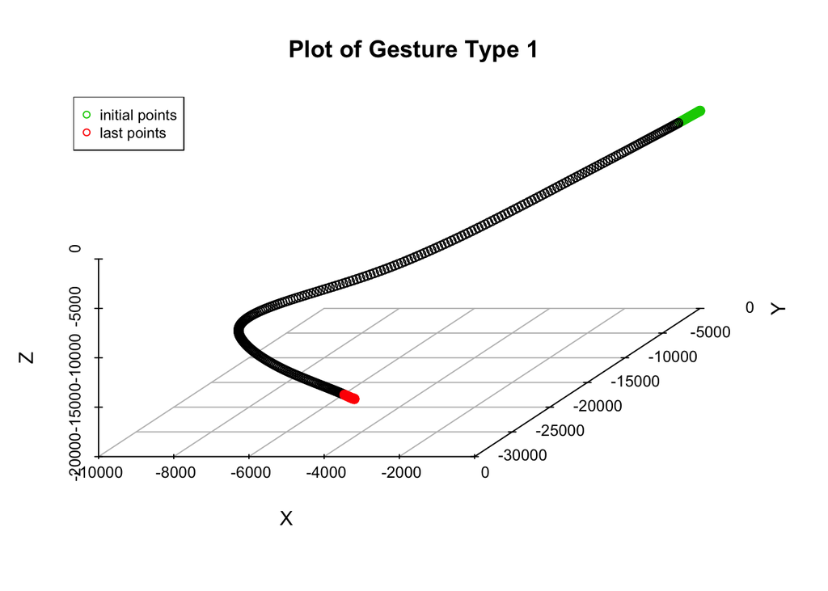

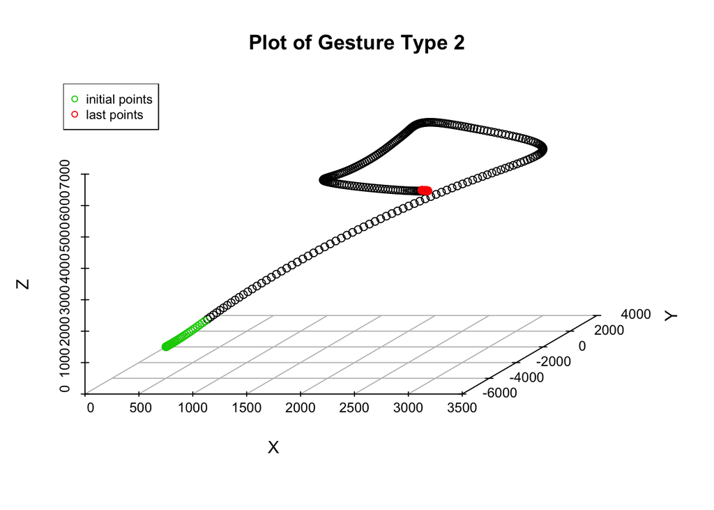

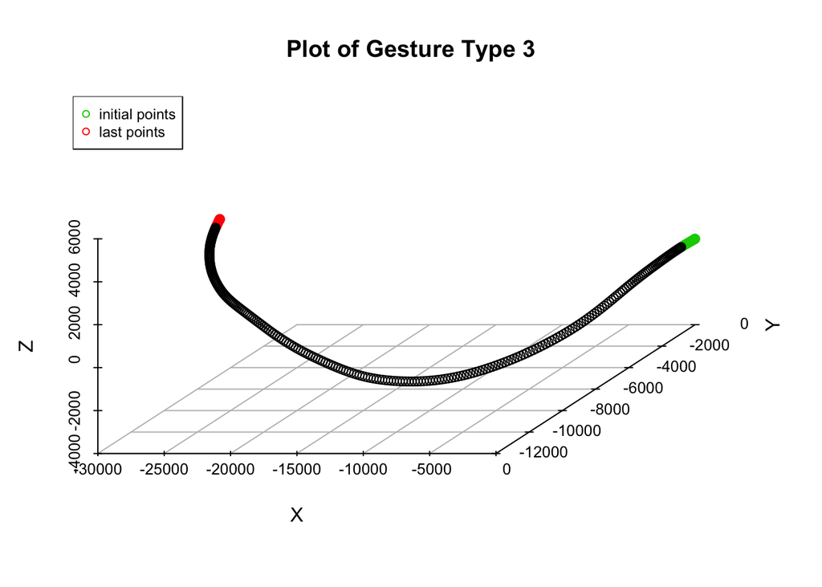

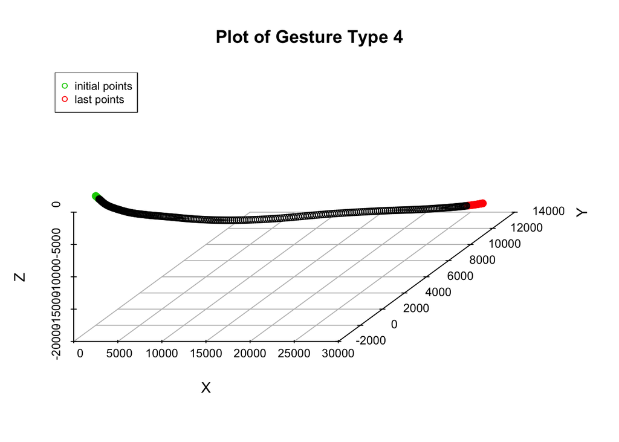

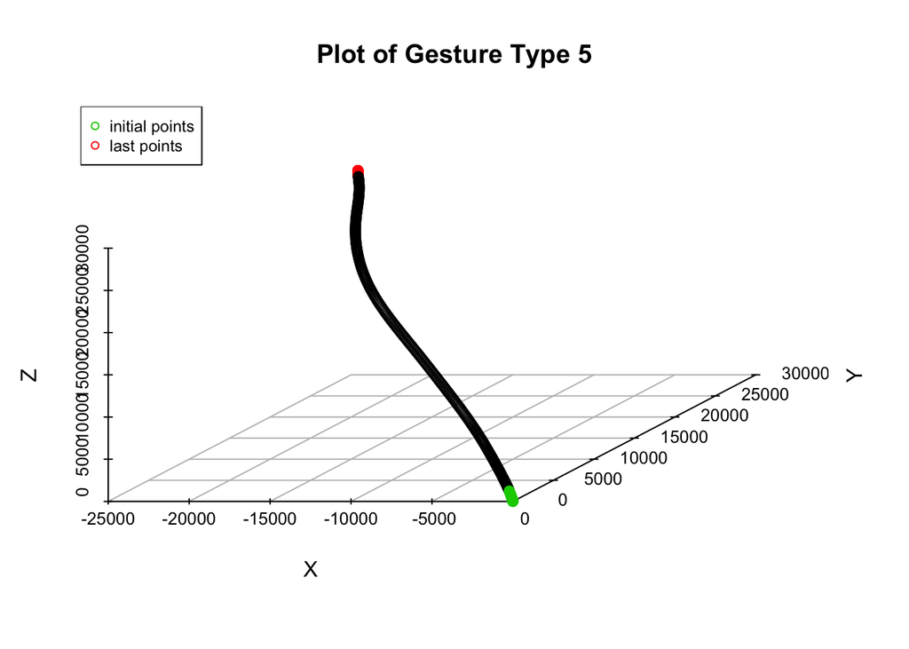

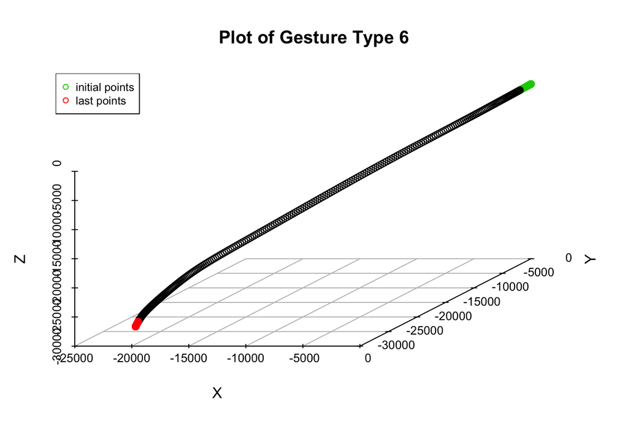

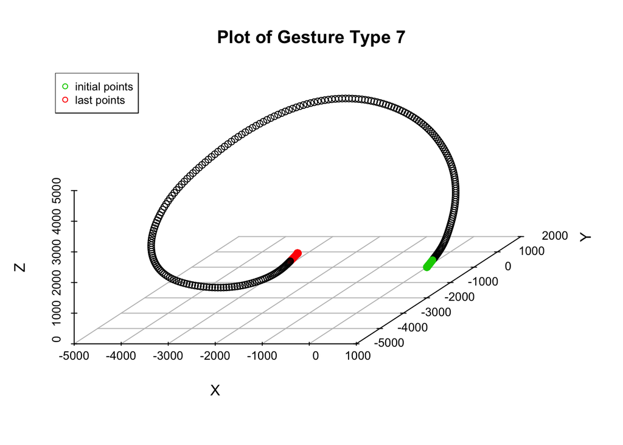

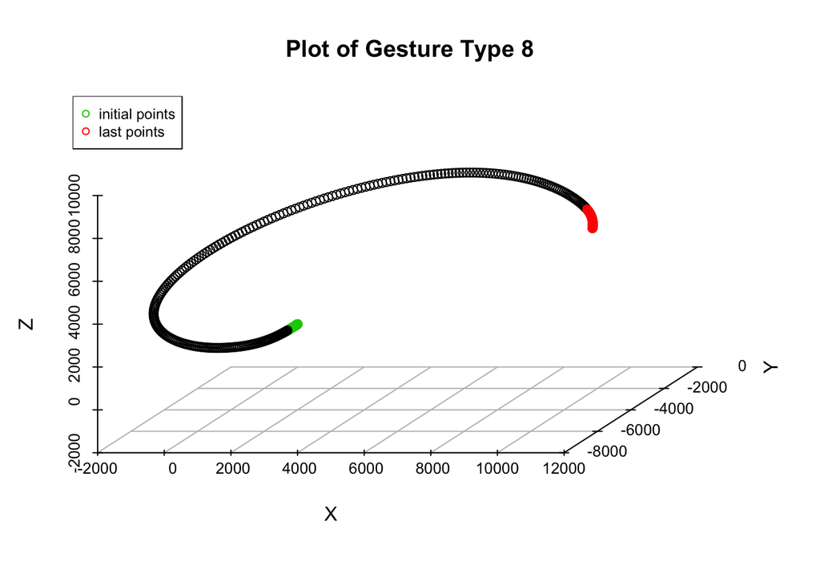

## Part B

In this part, we are asked to apply k-nearest neighbor classifier to predict the type of a gesture by considering similarity in the available acceleration information. After combining the information from each axis, we have 315*3=945 feature to represent each observation. Note that we have also class information(from 1 to 8) for each observation. Therefore, each observation is represented by 946 columns in total.

As a similarity measure, I utilized the euclidian distance in one approach, and manhattan distance in the other. “knn” function in “FNN” package uses directly euclidian distance while classifying the new points. On the other hand, kknn function in “kknn” package uses Minkowski distance. For Minkowski distance, if we set distance parameter as 1 in the kknn function, we can utilize Manhattan distance while classifying.

You can see how Minowski Distance is calculated below. To obtain Manhattan distance, set p=1.

$$MinkowskiDistance=(\sum_ {i=1}^n |x_i-y_i|^p)^{1/p}$$

Since the distance evaluation is required in both of the methods, the 945 feature is scaled before applying the methods. Finally, I need to determine the optimal value of k. By applying 10-fold cross-validation on the training set, I measured the accuracy with different k values with two distance measure. As a result of this, best k values are determined for each method among four candidates(k=1,3,5,7).

| Method | Distance | Klev | Accu |
| --- | --- | --- | --- |
| knn | Euclidian | 1 | 0.9419643 |
| knn | Euclidian | 3 | 0.9464286 |
| knn | Euclidian | 5 | 0.9430804 |
| knn | Euclidian | 7 | 0.9397321 |
| knn | Manhattan | 1 | 0.9553571 |
| knn | Manhattan | 3 | 0.9564732 |
| knn | Manhattan | 5 | 0.9464286 |
| knn | Manhattan | 7 | 0.9464286 |

As it can be seen from the table above, in both Euclidian and Manhattan cases, the highest accuracy is obtained for Klev=3. Therefore, in part C, k will be set as 3.

## Part C

#### k-NN with Euclidian Distance (k=3)

```
    Confussion Matrix
      1   2   3   4   5   6   7   8
  1 430   0   0   3   0   4   0   0
  2   1 449   0   0   0   0   2   0
  3   2   0 414   0  13  21   4   0
  4   6   0   0 372  59   7   0   6
  5   3   0   7   1 420   2   0   0
  6   8   0   5  17  27 391   1   0
  7   1   0   2   0   0   0 444   0
  8   0   0   0   1   1   0   0 458
```

```
Class Sizes Based on Predictions(From 1 to 8)
 451 449 428 394 520 425 451 464

Class Sizes Based on Actual Observations(From 1 to 8)
 437 452 454 450 433 449 447 460
Accuracy: 0.943
Time elapsed: 2.088 second.
```

#### k-NN with Manhattan Distance (k=3)

```
    Confussion Matrix
      1   2   3   4   5   6   7   8
  1 431   0   0   3   0   3   0   0
  2   1 451   0   0   0   0   0   0
  3   2   0 417   0  12  19   4   0
  4   3   0   0 383  49   8   0   7
  5   3   0   4   2 423   1   0   0
  6   6   0   4  14  26 399   0   0
  7   0   0   2   0   0   0 445   0
  8   0   0   0   1   1   0   0 458
```

```
Class Sizes Based on Predictions(From 1 to 8)
 446 451 427 403 511 430 449 465

Class Sizes Based on Actual Observations(From 1 to 8)
 437 452 454 450 433 449 447 460
Accuracy: 0.951
Time elapsed: 80.411 second.
```

# Question 2

In this question, we are asked to construct a logistic regression model on the training data using fused lasso penalties. By analyzing a time series data, we will clasify observations. In penalized regression approaches, the following objective function is minimized.

$$L(\lambda_1,\lambda_2,\beta)= |y-X\beta|^2+\lambda_2|\beta|^2+\lambda_1(\sum_ {i=2}^p |\beta_j-\beta_{j-1}|)$$

In the equation above, $\lambda_2$ will be set to 0. In this way, we will obtain a model with fused lasso penalties. To perform this task,“optL1” function in “penalized” package is utilized. This function does the cross validation itself to choose a $\lambda_1$ value that minimizing the error. Since coefficients are penalized, it is necessary to scale input data.

foldd<-as.data.table(ecg_model$fold) imbalance<-ecg_train_class[which(foldd$V1==1),]

## Part A & B

```
   Confussion Matrix
     0  1
  0 24 12
  1  6 58
```

In this model, optimal $\lambda_1$ is selected as 2.527864 by model’s itself. As a result of this selection, accuracy is obtained as 0.82. Below, you can see the coefficients of time series data. For a better understanding, you can also find the plot of coefficients.

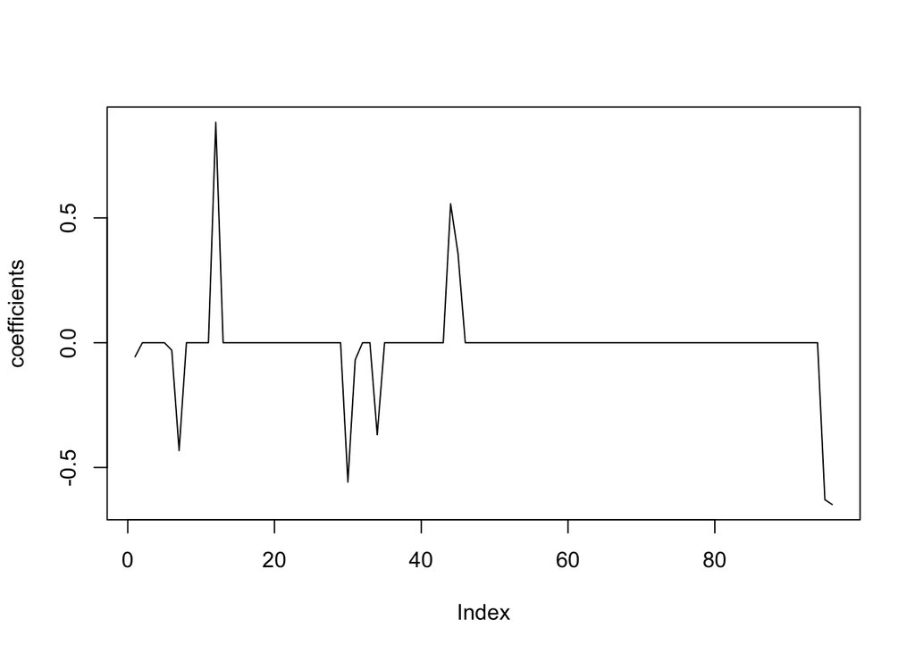

```r
ecg_model$fullfit@penalized
 [1] -0.05610555  0.00000000  0.00000000  0.00000000  0.00000000
 [6] -0.02989583 -0.43227807  0.00000000  0.00000000  0.00000000
[11]  0.00000000  0.88273501  0.00000000  0.00000000  0.00000000
[16]  0.00000000  0.00000000  0.00000000  0.00000000  0.00000000
[21]  0.00000000  0.00000000  0.00000000  0.00000000  0.00000000
[26]  0.00000000  0.00000000  0.00000000  0.00000000 -0.55828258
[31] -0.06823937  0.00000000  0.00000000 -0.36855403  0.00000000
[36]  0.00000000  0.00000000  0.00000000  0.00000000  0.00000000
[41]  0.00000000  0.00000000  0.00000000  0.55680262  0.35859971
[46]  0.00000000  0.00000000  0.00000000  0.00000000  0.00000000
[51]  0.00000000  0.00000000  0.00000000  0.00000000  0.00000000
[56]  0.00000000  0.00000000  0.00000000  0.00000000  0.00000000
[61]  0.00000000  0.00000000  0.00000000  0.00000000  0.00000000
[66]  0.00000000  0.00000000  0.00000000  0.00000000  0.00000000
[71]  0.00000000  0.00000000  0.00000000  0.00000000  0.00000000
[76]  0.00000000  0.00000000  0.00000000  0.00000000  0.00000000
[81]  0.00000000  0.00000000  0.00000000  0.00000000  0.00000000
[86]  0.00000000  0.00000000  0.00000000  0.00000000  0.00000000
[91]  0.00000000  0.00000000  0.00000000  0.00000000 -0.62885068
[96] -0.64816676
plot(ecg_model$fullfit@penalized,type="l",ylab="coefficients")
```

## Part C & D

In this part, we transformed the input data by applying the following equation: $y_t=x_t-x_{t-1}$ After this transformation, the size of input data is decreased by one obviously. Through applying the similar strategies above, confussion matrix and coefficients are obtained.

```
   Confussion Matrix
     0  1
  0 25 11
  1 12 52
```

In this model, optimal $\lambda_1$ is selected as 1.274577 by model’s itself.As a result of this selection, accuracy is obtained as 0.77. After this transofmation, more instance is predicted as 0, which actually causes an increase in the number of False Negatives. Accuracy rate decreases after this transformation.

Below, you can see the coefficients of transformed time series data and their plot.

```
 [1]  0.074014975  1.201699343  0.000000000 -0.562171351 -0.004618853
 [6]  0.000000000  0.204371121  0.272614586  0.465813925  0.082938887
[11]  0.027751285 -0.026370844  0.000000000  0.000000000  0.000000000
[16]  0.000000000  0.000000000  0.000000000  0.000000000  0.000000000
[21]  0.000000000  0.000000000  0.000000000  0.000000000  0.000000000
[26]  0.000000000  0.000000000 -0.613463809 -0.008167065  0.000000000
[31]  0.000000000  0.000000000  0.000000000  0.000000000  0.387012299
[36]  0.000000000  1.825375034  0.000000000  1.068628364  0.000000000
[41]  0.000000000  0.000000000  0.000000000  0.000000000  0.000000000
[46]  0.000000000  0.000000000  0.000000000  0.000000000  0.000000000
[51]  0.000000000  0.000000000  0.000000000  0.000000000  0.000000000
[56]  0.000000000  0.000000000  0.000000000  0.000000000  0.000000000
[61]  0.000000000  0.000000000  0.000000000  0.000000000  0.000000000
[66]  0.000000000  0.000000000  0.000000000  0.000000000  0.000000000
[71]  0.000000000  0.000000000  0.000000000  0.000000000  0.000000000
[76]  0.000000000 -1.500980872  0.000000000  0.000000000  0.000000000
[81]  0.000000000  0.000000000  0.000000000  0.000000000  0.000000000
[86]  0.000000000  0.000000000  0.000000000  0.000000000  0.000000000
[91]  0.000000000  0.000000000 -0.779074862 -0.511414853  0.000000000
```

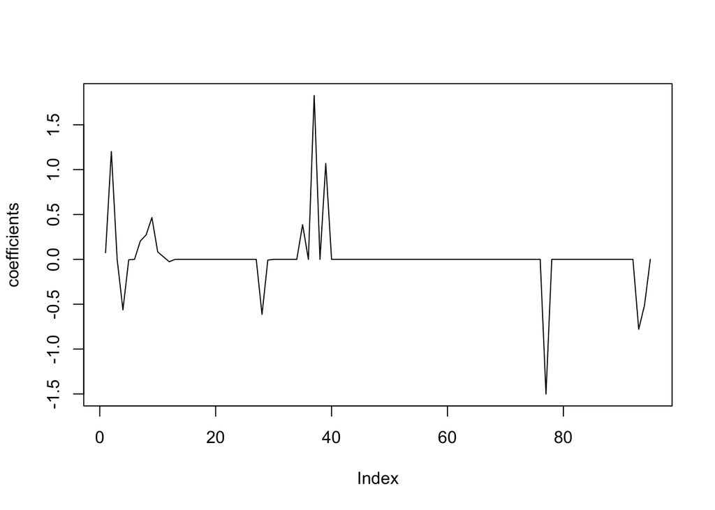